# Internet Overuse and Adolescent Sleep

Heather Leonard, Abbie Sanders, and Rebecca Gordon

12/08/2021

## Abstract

**Introduction:** Inadequate sleep has been linked to a host of negative outcomes in adolescents. One potential contributor to poor sleep in adolescents is the rise in cell phone access and use. This study explores the association of adolescent internet overuse and sleep outcomes. **Methods:** Data were collected from 345 middle school students (ages 12-14, 47% female) in the Pacific Northwest. Correlations were run on self-reported sleep measures (total sleep time per night and daytime sleepiness) and internet overuse. **Results:** Adolescent bedtime media use and internet overuse were positively correlated. Internet Overuse was also positively correlated with report of daytime sleepiness. **Conclusion:** These results indicate that bedtime media use among adolescents is related to overuse. Additionally, media overuse may negatively impact quality of life during the day.

## Introduction

Inadequate sleep has been linked to a host of negative outcomes in adolescents, including depression, anxiety, substance use, obesity, chronic inflammation, attentional focus, learning, and academic performance (Shochat, Cohen-Zion, and Tzischinsky 2014). The American Academy of Sleep Medicine recommends that adolescents get 8-10 hours of sleep per 24 hour period (Paruthi et al. 2016), yet most adolescents don’t meet that recommendation. One potential contributor to poor sleep in adolescents is the rise in cell phone access and use. According to a recent Pew Research Center survey, 95 percent of U.S. adolescents (ages 13-17) either own or have exclusive access to a smartphone (Anderson, Jiang, et al. 2018). Additionally, nearly half of adolescents’ waking time (7.5 hours per day) is spent on screen media devices, not including time spent in school or doing homework (Rideout 2015). According to a 2021 systematic review, internet overuse by adolescents contributes to both less total sleep and poor sleep quality (Kokka et al. 2021).

Given this information, the present study aims to explore the association of adolescent bedtime media use, internet overuse and sleep outcomes, including exploratory visuals and statistical summary of the data. Our research questions ask: 1) Is bedtime media use associated with internet overuse? 2) Is internet overuse associated with sleep outcomes(total sleep, daytime sleepiness) in adolescents?

## Methods

Data were collected from 345 middle school students in the Pacific Northwest. Parents were notified by mail and given the option to opt their student out of the survey. Student assent was collected by research assistants in the classroom prior to administering the survey. Students were compensated for their participation in the study. All procedures were approved by the institutional and school district review boards.

Total sleep was measured by asking for both weeknights and weekend nights, “what time do you usually go to bed?” and “what time do you usually wake up?” Responses were recorded on a 24-hour scale (range=0-24) and the final variable was created by rounding the difference in reported bedtimes and wake times. Values at the extreme ends were collapsed, and results were summarized into the following categories: 6 hours or less, 6-8 hours, 8-10 hours, and more than 10 hours.

Daytime sleepiness was measured by asking 8 questions (e.g., “how often do you fall asleep or get drowsy during class periods”) with response options ranging from (0) never to (4) always. Participants’ responses were added together to create a composite score (0-32).

Bedtime media use was measured by asking for both weeknights and weekend nights, “in the hour before you go to sleep, how frequently do you use any type of screen media?” Response options ranged from (0) never to (3) often.

Internet overuse was measured by asking 4 questions regarding internet use (e.g., “how often do you have trouble trying to cut down on the amount of time you spend online?” and “how often do your grades or schoolwork have suffered because of the amount of time you spend online?”). Response options ranged from (1) never to (4) often. Responses were added together to create a composite score (0-16; *M* = 9.8898551) , *SD* = 3.0393803).

We used the following packages on this assignment. Wickham et al. (2019), Chan et al. (2021), Sjoberg et al. (2021), and Müller (2020).

[output not shown]

```
## # A tibble: 1 × 3
##   `i don't know`    no   yes
##            <dbl> <dbl> <dbl>
## 1           9.65  9.64  10.1
```

## Results

Preliminary analysis included descriptive statistics of our demographic variables and our key variable for this paper (see Table 1).

**Table 1. Participant Characteristics**

| **Characteristic** | **N = 345**<sup>1</sup> |
| --- | --- |
| Grade |  |
| 7 | 163 (47%) |
| 8 | 182 (53%) |
| Age |  |
| 11 years | 2 (0.6%) |
| 12 years | 121 (35%) |
| 13 years | 186 (54%) |
| 14 years | 35 (10%) |
| i don't know | 1 (0.3%) |
| Sex |  |
| female | 161 (47%) |
| male | 183 (53%) |
| other | 1 (0.3%) |
| Ethnicity |  |
| hispanic or latino | 94 (27%) |
| non-hispanic or latino | 159 (46%) |
| unknown/refused | 92 (27%) |
| Free/reduced lunch |  |
| i don't know | 34 (9.9%) |
| no | 114 (33%) |
| yes | 197 (57%) |
| Race |  |
| american indian/alaska native | 19 (5.5%) |
| black or african american | 15 (4.3%) |
| more than one race | 123 (36%) |
| unknown | 60 (17%) |
| white or european american | 128 (37%) |
| Average daytime sleepiness | 16 (6) |
| Unknown | 8 |
| Average weekly hours of sleep per night |  |
| 6 hrs or less | 8 (2.4%) |
| 6-8 hrs | 64 (19%) |
| 8-10 hrs | 236 (70%) |
| More than 10 hrs | 30 (8.9%) |
| Unknown | 7 |
| Average internet overuse | 9.89 (3.04) |

<sup>*1*</sup> n (%); Mean (SD)

### *Research Question 1*

```
##
##  Pearson's product-moment correlation
##
## data:  synthdata$sl_bedmedia_bl and synthdata$io_comp
## t = 3.1186, df = 323, p-value = 0.001981
## alternative hypothesis: true correlation is not equal to 0
## 95 percent confidence interval:
##  0.06335282 0.27465048
## sample estimates:
##       cor
## 0.1709667
```

### *Research Question 2*

To examine the relationship between internet overuse and sleep outcomes, we ran two Pearson’s correlation analyses. First, we tested the association between internet overuse and average sleep on school nights. The results indicated that these two variables are not significantly associated r(337) = -0.04, *p* = .46. However, internet overuse was positively correlated with reported daytime sleepiness r(335) = .18, *p* < .001, indicating that as reports of internet overuse increase, reports of daytime sleepiness also increase.

```
##
##  Pearson's product-moment correlation
##
## data:  synthdata$io_comp and synthdata$sl_sleepschool_bl
## t = -0.74704, df = 337, p-value = 0.4556
## alternative hypothesis: true correlation is not equal to 0
## 95 percent confidence interval:
##  -0.14654445  0.06614568
## sample estimates:
##         cor
## -0.04065997
```

```
##
##  Pearson's product-moment correlation
##
## data:  synthdata$io_comp and synthdata$sl_sleepy_bl
## t = 3.3681, df = 335, p-value = 0.000845
## alternative hypothesis: true correlation is not equal to 0
## 95 percent confidence interval:
##  0.07560747 0.28235657
## sample estimates:
##       cor
## 0.1809808
```

## *Exploratory Visuals*

To examine the relationship between our correlation analyses and demographic variables, we rendered two scatter plots. Plot 1 shows the relationship between internet overuse and daytime sleepiness by adolescent age, faceted by welfare status. Plot 2 shows the relationship between internet overuse and average hours of sleep per night by adolescent age.

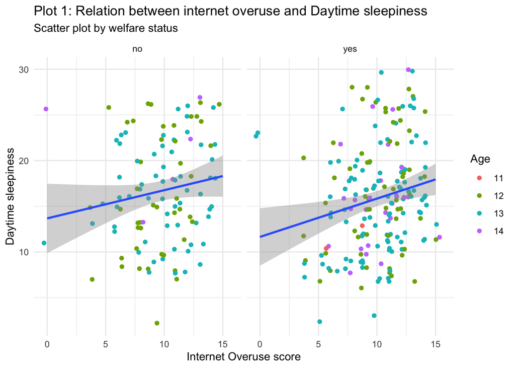

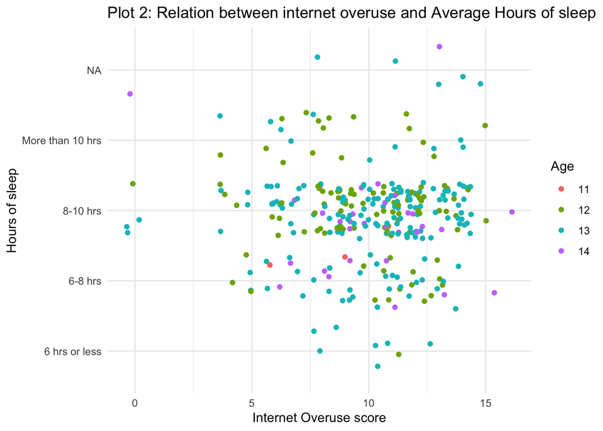

## Discussion

These results suggest that bedtime media use may lead to internet overuse among adolescents. Additionally, internet overuse may increase daytime sleepiness, but does not impact total hours of sleep. These findings indicate that media overuse in general may be harmful to quality of life for adolescents and that media devices are not as innocuous as they appear to be.

Overall, these findings indicate that media use among adolescents may be negatively impacting important aspects of their diurnal functioning.

### References

Anderson, Monica, Jingjing Jiang, et al. 2018. “Teens, Social Media & Technology 2018.” *Pew Research Center* 31 (2018): 1673–89.

Chan, Chung-hong, Geoffrey CH Chan, Thomas J. Leeper, and Jason Becker. 2021. *Rio: A Swiss-Army Knife for Data File i/o*.

Kokka, Ioulia, Iraklis Mourikis, Nicolas C Nicolaides, Christina Darviri, George P Chrousos, Christina Kanaka-Gantenbein, and Flora Bacopoulou. 2021. “Exploring the Effects of Problematic Internet Use on Adolescent Sleep: A Systematic Review.” *International Journal of Environmental Research and Public Health* 18 (2): 760.

Müller, Kirill. 2020. *Here: A Simpler Way to Find Your Files*. https://CRAN.R-project.org/package=here.

Paruthi, Shalini, Lee J Brooks, Carolyn D’Ambrosio, Wendy A Hall, Suresh Kotagal, Robin M Lloyd, Beth A Malow, et al. 2016. “Recommended Amount of Sleep for Pediatric Populations: A Consensus Statement of the American Academy of Sleep Medicine.” *Journal of Clinical Sleep Medicine* 12 (6): 785–86.

Rideout, Vicky. 2015. “The Common Sense Census: Media Use by Tweens and Teens.”

Shochat, Tamar, Mairav Cohen-Zion, and Orna Tzischinsky. 2014. “Functional Consequences of Inadequate Sleep in Adolescents: A Systematic Review.” *Sleep Medicine Reviews* 18 (1): 75–87.

Sjoberg, Daniel D., Karissa Whiting, Michael Curry, Jessica A. Lavery, and Joseph Larmarange. 2021. “Reproducible Summary Tables with the Gtsummary Package.” *The R Journal* 13: 570–80. https://doi.org/10.32614/RJ-2021-053.

Wickham, Hadley, Mara Averick, Jennifer Bryan, Winston Chang, Lucy D’Agostino McGowan, Romain François, Garrett Grolemund, et al. 2019. “Welcome to the Tidyverse.” *Journal of Open Source Software* 4 (43): 1686.